# Seed Classification Report

## Overview

This report presents a comprehensive analysis and classification of different seed types using decision tree models.

## 1. Importing Libraries and preparing the Dataset

We begin by loading the necessary libraries and reading in the dataset.

```r
# Load necessary packages
library(tidyverse)
library(caret)
```

```r
library(rpart)
library(rpart.plot)
library(corrplot)
# Import the dataset
seeds <- read.csv("C:/Users/Samir/OneDrive - IMC/Desktop/ML/seeds.csv")


# Check for missing values
sum(is.na(seeds))
```

```
## [1] 4
```

We found a few missing values. We remove any rows containing NA values and then verify dataset is clean.

```r
# Remove rows with missing values
seeds <- na.omit(seeds)


# Check again to confirm
sum(is.na(seeds))
```

```
## [1] 0
```

Now we inspect the structure of the dataset and convert the target column (Class) to a factor.

```r
# Check the structure of the dataset
str(seeds)
```

```
## 'data.frame':    8205 obs. of  17 variables:
##  $ Area           : int  37663 25423 36982 38687 32795 26163 42522 42242 35699 38782 ...
##  $ Perimeter      : num  712 590 709 722 651 ...
##  $ MajorAxisLength: num  234 221 244 266 225 ...
##  $ MinorAxisLength: num  206 146 193 185 186 ...
##  $ AspectRation   : num  1.13 1.51 1.27 1.44 1.21 ...
##  $ Eccentricity   : num  0.473 0.751 0.614 0.717 0.566 ...
##  $ ConvexArea     : int  38084 25739 37558 39030 33091 26435 43001 42734 36104 39152 ...
##  $ EquivDiameter  : num  219 180 217 222 204 ...
##  $ Extent         : num  0.754 0.764 0.76 0.804 0.776 ...
##  $ Solidity       : num  0.989 0.988 0.985 0.991 0.991 ...
##  $ roundness      : num  0.933 0.917 0.925 0.932 0.972 ...
##  $ Compactness    : num  0.938 0.812 0.888 0.834 0.907 ...
##  $ ShapeFactor1   : num  0.0062 0.00871 0.00661 0.00688 0.00687 ...
##  $ ShapeFactor2   : num  0.00296 0.00234 0.00253 0.00205 0.00287 ...
##  $ ShapeFactor3   : num  0.879 0.66 0.788 0.696 0.823 ...
##  $ ShapeFactor4   : num  0.997 0.999 0.998 0.998 0.999 ...
##  $ Class          : chr  "SEKER" "DERMASON" "SEKER" "SIRA" ...
##  - attr(*, "na.action")= 'omit' Named int [1:4] 15 21 41 57
##   ..- attr(*, "names")= chr [1:4] "15" "21" "41" "57"
```

```r
# Convert the 'Class' column to a factor
seeds$Class <- as.factor(seeds$Class)

# Check for confirmation
str(seeds$Class)
```

```
##  Factor w/ 3 levels "DERMASON","SEKER",..: 2 1 2 3 2 1 3 3 2 1 ...
```

Finally for this part, we generate summary statistics to understand the spread and scale of each feature.

```r
# View summary statistics of the dataset
summary(seeds)
```

```
##       Area         Perimeter     MajorAxisLength MinorAxisLength
##  Min.   :20420   Min.   :524.7   Min.   :183.6   Min.   :122.5
##  1st Qu.:32771   1st Qu.:669.4   1st Qu.:240.6   1st Qu.:168.2
##  Median :38137   Median :720.6   Median :260.1   Median :185.3
##  Mean   :38086   Mean   :722.8   Mean   :264.7   Mean   :182.7
##  3rd Qu.:43315   3rd Qu.:776.8   3rd Qu.:287.2   3rd Qu.:196.5
##  Max.   :63612   Max.   :984.3   Max.   :400.9   Max.   :252.3
##   AspectRation    Eccentricity      ConvexArea    EquivDiameter
##  Min.   :1.025   Min.   :0.2190   Min.   :20684   Min.   :161.2
##  1st Qu.:1.346   1st Qu.:0.6695   1st Qu.:33133   1st Qu.:204.3
##  Median :1.479   Median :0.7369   Median :38554   Median :220.4
##  Mean   :1.456   Mean   :0.7090   Mean   :38521   Mean   :219.2
##  3rd Qu.:1.564   3rd Qu.:0.7688   3rd Qu.:43828   3rd Qu.:234.8
##  Max.   :2.010   Max.   :0.8675   Max.   :64581   Max.   :284.6
##      Extent          Solidity        roundness       Compactness
##  Min.   :0.6275   Min.   :0.9192   Min.   :0.4896   Min.   :0.7034
##  1st Qu.:0.7276   1st Qu.:0.9875   1st Qu.:0.8884   1st Qu.:0.7982
##  Median :0.7630   Median :0.9891   Median :0.9102   Median :0.8208
##  Mean   :0.7565   Mean   :0.9887   Mean   :0.9096   Mean   :0.8313
##  3rd Qu.:0.7861   3rd Qu.:0.9905   3rd Qu.:0.9329   3rd Qu.:0.8608
##  Max.   :0.8528   Max.   :0.9942   Max.   :0.9907   Max.   :0.9873
##   ShapeFactor1       ShapeFactor2       ShapeFactor3     ShapeFactor4
##  Min.   :0.005056   Min.   :0.000987   Min.   :0.4947   Min.   :0.9477
##  1st Qu.:0.006502   1st Qu.:0.001770   1st Qu.:0.6372   1st Qu.:0.9959
##  Median :0.006898   Median :0.002067   Median :0.6737   Median :0.9974
##  Mean   :0.007072   Mean   :0.002101   Mean   :0.6933   Mean   :0.9968
##  3rd Qu.:0.007594   3rd Qu.:0.002400   3rd Qu.:0.7410   3rd Qu.:0.9984
##  Max.   :0.010451   Max.   :0.003665   Max.   :0.9748   Max.   :0.9997
##       Class
##  DERMASON:3545
##  SEKER   :2025
##  SIRA    :2635
##
##
##
```

## 2. Data Exploration

We begin our data exploration by visualizing the distributions of some key features across the three seed types using boxplots.

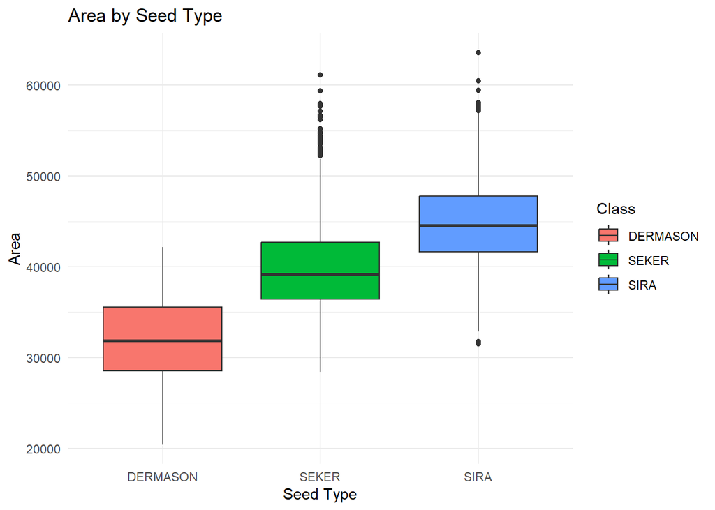

```r
# Boxplot of Area by Class
ggplot(seeds, aes(x = Class, y = Area, fill = Class)) +
  geom_boxplot() +
  theme_minimal() +
  labs(title = "Area by Seed Type", y = "Area", x = "Seed Type")
```

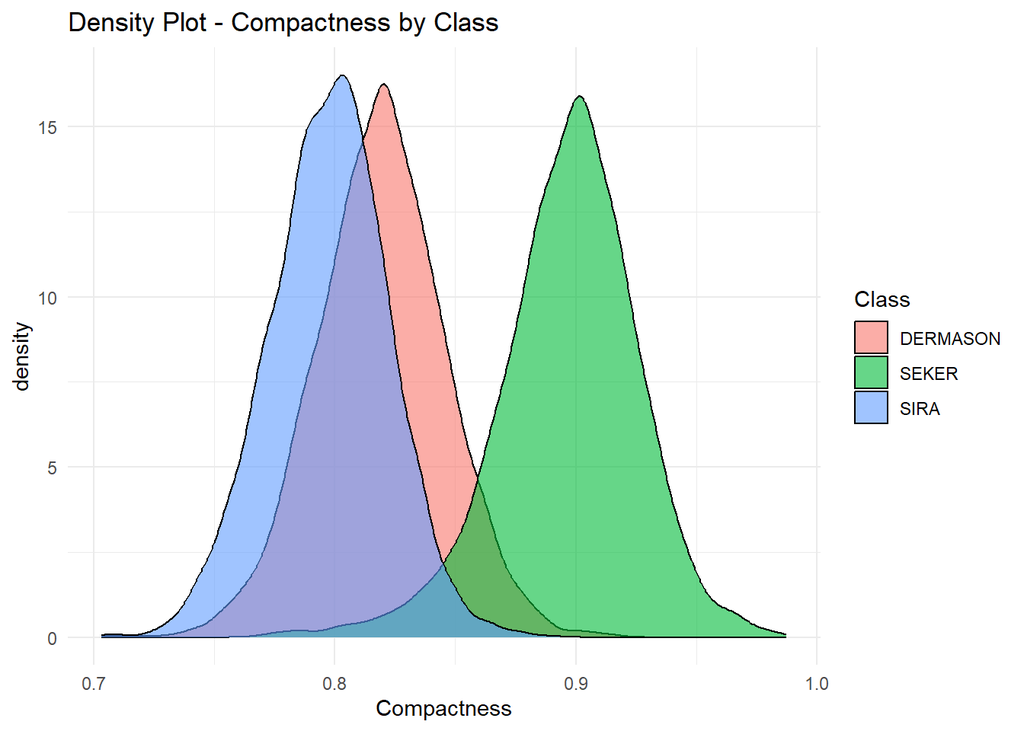

```r
# Density plot of Compactness by Class
ggplot(seeds, aes(x = Compactness, fill = Class)) +
  geom_density(alpha = 0.6) +
  labs(title = "Density Plot - Compactness by Class") +
  theme_minimal()
```

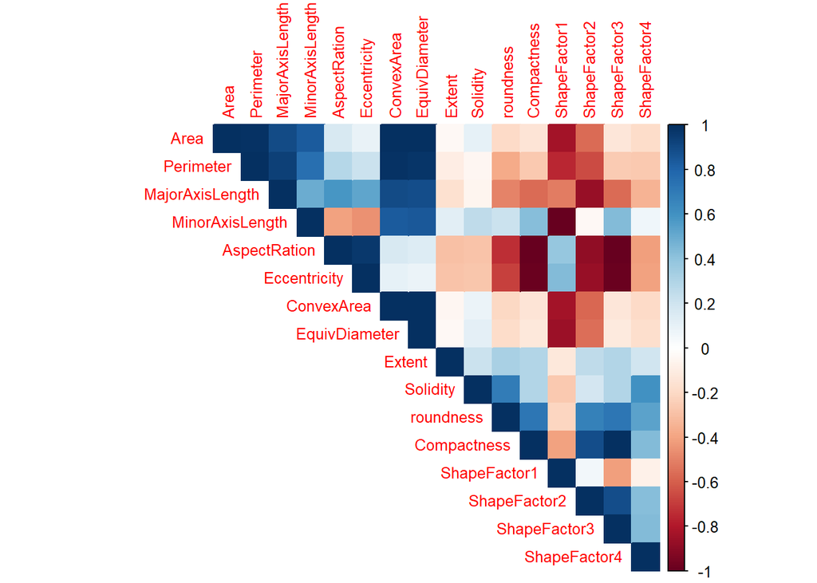

```r
# Correlation heatmap (excluding Class)
cor_matrix <- cor(seeds %>% select(-Class))
corrplot(cor_matrix, method = "color", type = "upper", tl.cex = 0.8)
```

## 3. Splitting the Dataset

We split the dataset into a training set (80%) and a test set (20%) using the `caret` package.

```r
# Set seed for reproduction
set.seed(123)

# Create the train/test split index
split_index <- createDataPartition(seeds$Class, p = 0.8, list = FALSE)

# Split the data
train_data <- seeds[split_index, ]
test_data <- seeds[-split_index, ]

# Check the dimensions of each set
dim(train_data)
```

```
## [1] 6564   17
```

```r
dim(test_data)
```

```
## [1] 1641   17
```

## 4a. Training a Decision Tree (Default Stopping Criteria)

We train a decision tree classifier using default stopping rules.

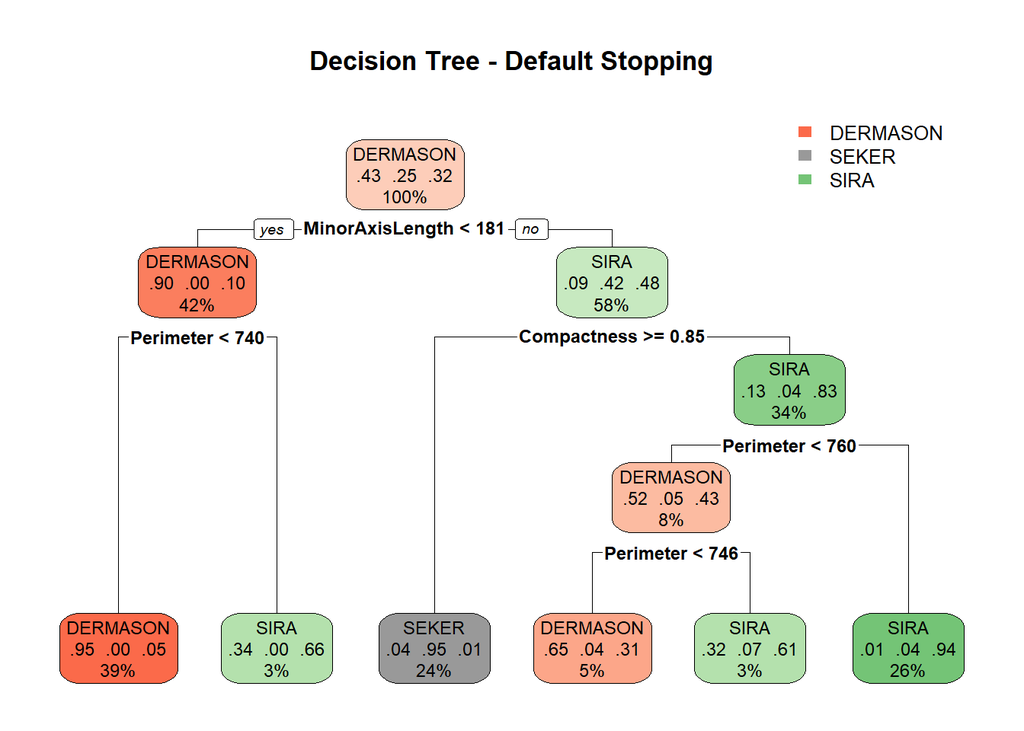

```r
# Train the decision tree model with default settings
tree_default <- rpart(Class ~ ., data = train_data, method = "class")

# Plot the decision tree
rpart.plot(tree_default, main = "Decision Tree - Default Stopping")
```

## 4b.Training a Full Grown Decision Tree (Without Stopping Criteria)

We’ll force the tree to grow as much as possible by adjusting the control parameters minsplit and cp.

[figure not shown]

```r
# Train a fully grown decision tree
tree_full <- rpart(Class ~ ., data = train_data, method = "class",
                   control = rpart.control(cp = 0, minsplit = 1))

# Plot the fully grown tree
rpart.plot(tree_full, main = "Fully Grown Decision Tree")
```

## 4c. Pruning the Fully Grown Tree

We now prune the fully grown tree from step 4b to reduce overfitting. We begin by examining the complexity parameter (cp) table, which shows how error changes with each level of pruning. Then we identify the cp value that minimizes the cross-validation error and prune the tree accordingly.

```r
# Display the complexity parameter table
printcp(tree_full)
```

```
##
## Classification tree:
## rpart(formula = Class ~ ., data = train_data, method = "class",
##     control = rpart.control(cp = 0, minsplit = 1))
##
## Variables actually used in tree construction:
##  [1] Area            AspectRation    Compactness     ConvexArea
##  [5] Extent          MajorAxisLength MinorAxisLength Perimeter
##  [9] roundness       ShapeFactor1    ShapeFactor2    ShapeFactor4
## [13] Solidity
##
## Root node error: 3728/6564 = 0.56795
##
## n= 6564
##
```

[output cut: 28 more lines]

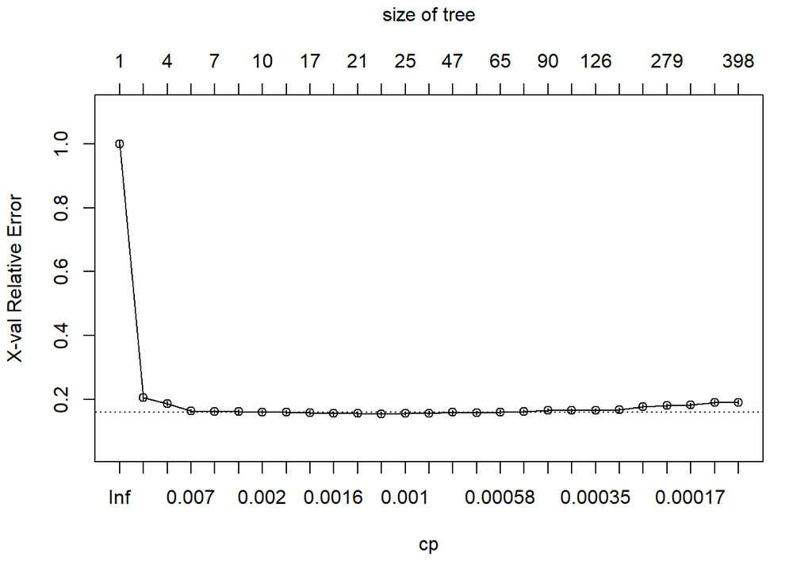

```r
# Visualize cp vs. cross-validation error
plotcp(tree_full)
```

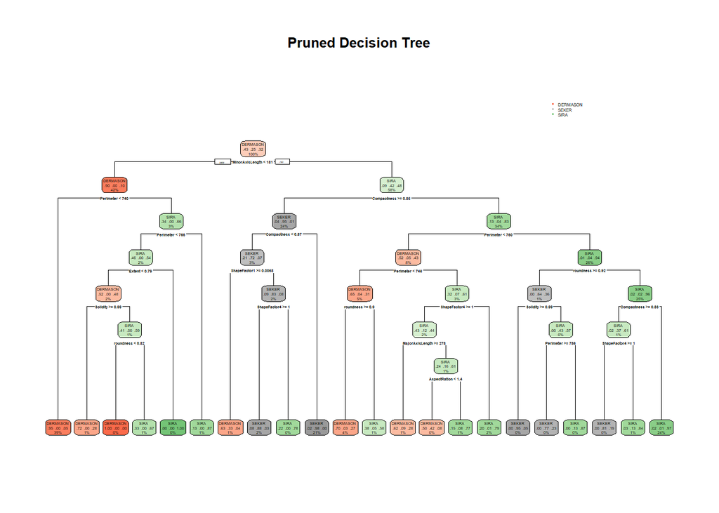

```r
# Select the best cp value (lowest cross-validation error)
best_cp <- tree_full$cptable[which.min(tree_full$cptable[, "xerror"]), "CP"]

# Prune the tree using the optimal cp value
tree_pruned <- prune(tree_full, cp = best_cp)

# Plot the pruned tree
rpart.plot(tree_pruned, main = "Pruned Decision Tree")
```

## 5. Model Evaluation

We now compare the performance of the three models — default, fully grown, and pruned — using the test set.

```r
# Predict using default tree
pred_default <- predict(tree_default, test_data, type = "class")
confusionMatrix(pred_default, test_data$Class)
```

```
## Confusion Matrix and Statistics
##
##           Reference
## Prediction DERMASON SEKER SIRA
##   DERMASON      651    11   58
##   SEKER          14   374    6
##   SIRA           44    20  463
##
## Overall Statistics
##
##                Accuracy : 0.9068
##                  95% CI : (0.8917, 0.9204)
##     No Information Rate : 0.4321
##     P-Value [Acc > NIR] : < 2e-16
##
##                   Kappa : 0.8561
##
##  Mcnemar's Test P-Value : 0.02016
##
## Statistics by Class:
##
##                      Class: DERMASON Class: SEKER Class: SIRA
## Sensitivity                   0.9182       0.9235      0.8786
## Specificity                   0.9260       0.9838      0.9425
## Pos Pred Value                0.9042       0.9492      0.8786
## Neg Pred Value                0.9370       0.9751      0.9425
## Prevalence                    0.4321       0.2468      0.3211
## Detection Rate                0.3967       0.2279      0.2821
## Detection Prevalence          0.4388       0.2401      0.3211
## Balanced Accuracy             0.9221       0.9536      0.9106
```

```r
# Predict using fully grown tree
pred_full <- predict(tree_full, test_data, type = "class")
confusionMatrix(pred_full, test_data$Class)
```

```
## Confusion Matrix and Statistics
##
##           Reference
## Prediction DERMASON SEKER SIRA
##   DERMASON      647    20   64
##   SEKER           9   372    8
##   SIRA           53    13  455
##
## Overall Statistics
##
##                Accuracy : 0.8982
##                  95% CI : (0.8826, 0.9124)
##     No Information Rate : 0.4321
##     P-Value [Acc > NIR] : < 2e-16
##
##                   Kappa : 0.8427
##
##  Mcnemar's Test P-Value : 0.09381
##
## Statistics by Class:
##
##                      Class: DERMASON Class: SEKER Class: SIRA
## Sensitivity                   0.9126       0.9185      0.8634
## Specificity                   0.9099       0.9862      0.9408
## Pos Pred Value                0.8851       0.9563      0.8733
## Neg Pred Value                0.9319       0.9736      0.9357
## Prevalence                    0.4321       0.2468      0.3211
## Detection Rate                0.3943       0.2267      0.2773
## Detection Prevalence          0.4455       0.2371      0.3175
## Balanced Accuracy             0.9112       0.9524      0.9021
```

```r
# Predict using pruned tree
pred_pruned <- predict(tree_pruned, test_data, type = "class")
confusionMatrix(pred_pruned, test_data$Class)
```

```
## Confusion Matrix and Statistics
##
##           Reference
## Prediction DERMASON SEKER SIRA
##   DERMASON      666    16   61
##   SEKER           6   377    7
##   SIRA           37    12  459
##
## Overall Statistics
##
##                Accuracy : 0.9153
##                  95% CI : (0.9008, 0.9283)
##     No Information Rate : 0.4321
##     P-Value [Acc > NIR] : < 2.2e-16
##
##                   Kappa : 0.8689
##
##  Mcnemar's Test P-Value : 0.008334
##
## Statistics by Class:
##
##                      Class: DERMASON Class: SEKER Class: SIRA
## Sensitivity                   0.9394       0.9309      0.8710
## Specificity                   0.9174       0.9895      0.9560
## Pos Pred Value                0.8964       0.9667      0.9035
## Neg Pred Value                0.9521       0.9776      0.9400
## Prevalence                    0.4321       0.2468      0.3211
## Detection Rate                0.4059       0.2297      0.2797
## Detection Prevalence          0.4528       0.2377      0.3096
## Balanced Accuracy             0.9284       0.9602      0.9135
```

## 6. Repeating only three features

We now repeat the classification task using only three features: Area, Perimeter, and Compactness.

## 6a. Prepare the data with selected features

```r
# Select only three features + target
seeds_small <- seeds %>% select(Area, Perimeter, Compactness, Class)

# Train/test split
set.seed(123)
split_index_small <- createDataPartition(seeds_small$Class, p = 0.8, list = FALSE)
train_small <- seeds_small[split_index_small, ]
test_small <- seeds_small[-split_index_small, ]
```

## 6b. Train and evaluate decision tree (default)

```r
# Train model with default settings
tree_small <- rpart(Class ~ ., data = train_small, method = "class")

# Predict on test set
pred_small <- predict(tree_small, test_small, type = "class")

# Evaluate
confusionMatrix(pred_small, test_small$Class)
```

```
## Confusion Matrix and Statistics
##
##           Reference
## Prediction DERMASON SEKER SIRA
##   DERMASON      657    16   61
##   SEKER          13   364    5
##   SIRA           39    25  461
##
## Overall Statistics
##
##                Accuracy : 0.9031
##                  95% CI : (0.8878, 0.917)
##     No Information Rate : 0.4321
##     P-Value [Acc > NIR] : < 2.2e-16
##
##                   Kappa : 0.8501
##
##  Mcnemar's Test P-Value : 0.0003495
##
## Statistics by Class:
##
##                      Class: DERMASON Class: SEKER Class: SIRA
## Sensitivity                   0.9267       0.8988      0.8748
## Specificity                   0.9174       0.9854      0.9425
## Pos Pred Value                0.8951       0.9529      0.8781
## Neg Pred Value                0.9427       0.9674      0.9409
## Prevalence                    0.4321       0.2468      0.3211
## Detection Rate                0.4004       0.2218      0.2809
## Detection Prevalence          0.4473       0.2328      0.3199
## Balanced Accuracy             0.9220       0.9421      0.9087
```

## 6c. Comparison and Conclusion

The accuracy and metrics from the three-features model (Area, Perimeter, Compactness) can now be compared with the full-feature models. Based on the confusion matrix, we observe that accuracy slightly decreased from 91% to 90%.